# Geog533 Lab 8

Yalin Yang

Complete the following exercises in Chapter 8 (Introduction to Regression Analysis) of the textbook [R] pages 247-250.

## Question 1

This is Exercise 1 in Chapter 8 of the Textbook [R].

A regression of weekly shopping trip frequency on annual income (data entered in thousands of dollars) is performed on data collected from 24 respondents. The results are summarized below:

- Intercept: 0.46
- Slope: 0.19

|  | Sum of squares | Degrees of freedom | Mean square | *F* |
| --- | --- | --- | --- | --- |
| Regression | 0.6 | 1 | 0.6 | 7.7647059 |
| Residual | 1.7 | 22 | 0.0772727 |  |
| Total | 2.3 | 23 |  |  |

### Question 1(a)

Fill in the blanks in the ANOVA table.

|  | Sum of squares | Degrees of freedom | Mean square | *F* |
| --- | --- | --- | --- | --- |
| Regression | 0.6 | 1 | 0.6 | 7.7647059 |
| Residual | 1.7 | 22 | 0.0772727 |  |
| Total | 2.3 | 23 |  |  |

### Question 1(b)

What is the predicted number of weekly shopping trips for someone making $50,000/year?

```r
Shop_time <- 0.19*50+0.46
print(paste('the predicted number of weekly shopping trips is',Shop_time))
```

```
[1] "the predicted number of weekly shopping trips is 9.96"
```

### Question 1(c)

In words, what is the meaning of the coefficient 0.19?

```r
print('There was a positive correlation between independent variables and dependent variables, when independent variables changes 1, the dependent variable will change 0.19')
```

```
[1] "There was a positive correlation between independent variables and dependent variables, when independent variables changes 1, the dependent variable will change 0.19"
```

### Question 1(d)

Is the regression coefficient significantly different from zero? How do you know?

```r
one_F <- (2.3-1.7)/1/(1.7/(24-2))
if(one_F > qf(0.95,df = 1,df2 = 22))
{
  print('it is significant beacuse the F value in the rejection area')

}
```

```
[1] "it is significant beacuse the F value in the rejection area"
```

### Question 1(e)

What is the value of the correlation coefficient?

```r
one_F <- (2.3-1.7)/1/(1.7/(24-2))
r2 <- (24-2)/one_F + 1
R <- sqrt(1/r2)
R
```

```
[1] 0.5107539
```

## Question 2

This is Exercise 6 in Chapter 8 of the Textbook [R].

The following data are collected in an effort to determine whether snowfall is dependent upon elevation:

| Snowfall (inches) | Elevation (feet) |
| --- | --- |
| 36 | 400 |
| 78 | 800 |
| 11 | 200 |
| 45 | 675 |

Using R, show your work on exercises (a) through (g).

### Question 2(a)

Find the regression coefficients (the intercept and the slope coefficient).

```r
y <- c(36,78,11,45)
x <- c(400,800,200,675)
m <- lm(y~x)
slope <- m$coefficients[2][[1]]
intercept <- m$coefficients[1][[1]]
print(paste('intercept is ',round(intercept,4) ,'and slope is ',round(slope,4)))
```

```
[1] "intercept is  -7.6372 and slope is  0.0967"
```

### Question 2(b)

Estimate the standard error of the residuals about the regression line.

```r
a <- summary(m)
summary(m)
```

```
Call:
lm(formula = y ~ x)

Residuals:
       1        2        3        4
  4.9772   8.3172  -0.6928 -12.6016

Coefficients:
            Estimate Std. Error t value Pr(>|t|)
(Intercept) -7.63721   13.67764  -0.558   0.6328
x            0.09665    0.02403   4.022   0.0566 .
---
Signif. codes:  0 *** 0.001 ** 0.01 * 0.05 . 0.1   1

Residual standard error: 11.25 on 2 degrees of freedom
Multiple R-squared:  0.8899,    Adjusted R-squared:  0.8349
F-statistic: 16.17 on 1 and 2 DF,  p-value: 0.05663
```

```r
sd.err<- sqrt(sum((a$residuals - mean(a$residuals))^2)/(4-2))
print(paste('the standard error of the residuals is ',round(sd.err,digits = 5)))
```

```
[1] "the standard error of the residuals is  11.25227"
```

### Question 2(c)

Test the hypothesis that the regression coefficient associated with the independent variables is equal to zero. Also place a 95% confidence interval on the regression coefficient.

```r
result <- anova(m)
if (result$`Pr(>F)`[1] > 0.05)
{
  print('it is not signigicant')
}
```

```
[1] "it is not signigicant"
```

### Question 2(d)

Find the value of $r^2$.

```r
result.err<- cor.test(x,y,method = 'pearson')
R <- (result.err$estimate[[1]]^2)
R
```

```
[1] 0.889949
```

### Question 2(e)

Make a table of the observed values, predicted values, and the residuals.

```r
b <- summary(m)
df <- data.frame(y,fitted(m),b$residuals)
head(df)
```

|  | y | fitted.m. | b.residuals |
| --- | --- | --- | --- |
| 1 | 36 | 31.02281 | 4.9771917 |
| 2 | 78 | 69.68282 | 8.3171775 |
| 3 | 11 | 11.69280 | -0.6928011 |
| 4 | 45 | 57.60157 | -12.6015681 |

### Question 2(f)

Prepare an analysis of variance table portraying the regression results.

```r
anova(m)
```

```
Analysis of Variance Table

Response: y
          Df  Sum Sq Mean Sq F value  Pr(>F)
x          1 2047.77 2047.77  16.173 0.05663 .
Residuals  2  253.23  126.61
---
Signif. codes:  0 *** 0.001 ** 0.01 * 0.05 . 0.1   1
```

[output not shown]

### Question 2(g)

Graph the data and the regression line.

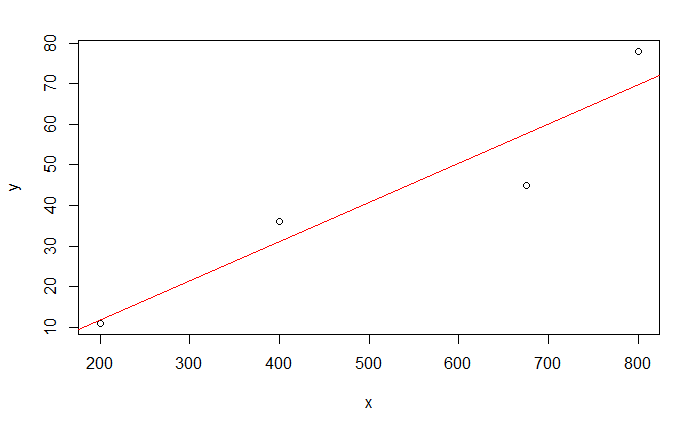

```r
plot(x,y)
abline(m,col='red')
```

## Question 3

This is Exercise 10 in Chapter 8 of the Textbook [R].

### Solution

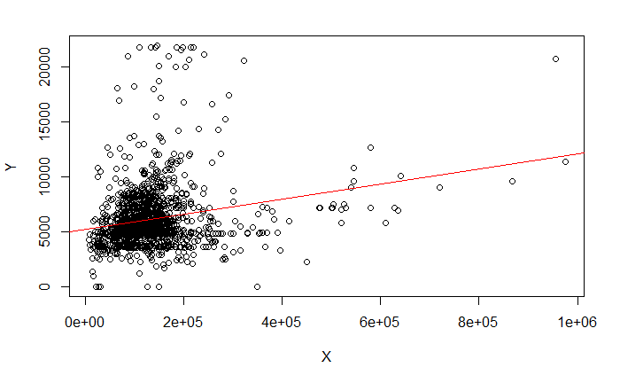

```r
url = "http://spatial.binghamton.edu/geog533/data/Milwaukee_Sales.csv"
df <- read.csv(file = url)
X <- df$SalePrice
Y <- df$LotSize
plot(X,Y)
M<- lm(Y~X)
abline(M,col='red')
```

## Question 4

This is Exercise 11 in Chapter 8 of the Textbook [R].

Use R and the Hypothetical [UK Housing Prices dataset](http://spatial.binghamton.edu/geog533/data/UK_Housing.csv) to:

### Question 4(a)

perform a regression using house price as the dependent variable, and number of bedrooms as the independent variable;

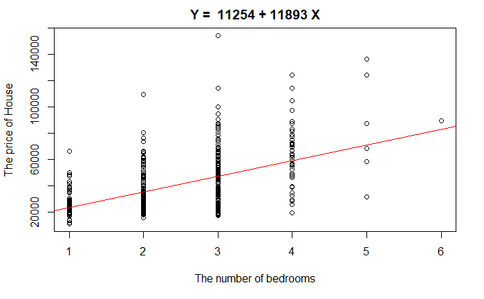

```r
url = "http://spatial.binghamton.edu/geog533/data/UK_Housing.csv"
df_new <- read.csv(file = url)
p <- df_new$price
o <- df_new$bedrooms
m <- lm(p~o)
equa<- paste('Y = ',round(m[[1]][[1]],digits = 0),'+',round(m[[1]][[2]],digits = 0),'X')
plot(o,p,main = equa,ylab = 'The price of House',xlab = 'The number of bedrooms')
abline(m,col='red')
```

### Question 4(b)

2. repeat part (a), using the number of bathrooms as the independent variable, and comment on the results.

[figure not shown]

```r
df_new <- read.csv(file = url)
j <- df_new$price
k <- df_new$bathrooms
m_new <- lm(j~k)
equa_new <- paste('Y = ',round(m_new[[1]][[1]],digits = 0),'+',round(m_new[[1]][[2]],digits = 0),'X')
plot(k,j,main = equa_new,ylab = 'The price of House',xlab = 'The number of bathrooms')
abline(m,col='red')
```

## Question 5

Download the hometown.csv, append your name and hometown coordinates to the csv, then use [leaflet](https://rstudio.github.io/leaflet/) to create a web map (10 pt.)

```r
url = 'http://spatial.binghamton.edu/geog533/data/hometown.csv'
df_yyl <- read.csv(file = url)
fix <- c('yang','yalin','grads','106.481,29.590','106.481','29.590','','','')
df_yyl <- as.data.frame(rbind(as.matrix(df_yyl) , fix))
df_yyl[25:34,]
```

|  | lastname | firstname | type | location | latitude | longitude | image | fullname | popup |
| --- | --- | --- | --- | --- | --- | --- | --- | --- | --- |
|  | Wen | Hao | grads | 23.130560, 113.254352 | 23.130560 | 113.254352 | http://binghamton.edu/geography/images/graduatestudent15/wen_hao.jpg | Hao Wen | Hao Wen |
| .1 | Harris | Tammie | grads | 42.241933, -75.021875 | 42.241933 | -75.021875 | http://binghamton.edu/geography/images/graduatestudent15/tammie_harris.jpg | Tammie Harris | Tammie Harris |
| .2 | Jiang | Jiaxin | grads | 31.233876, 112.588013 | 31.233876 | 112.588013 | http://binghamton.edu/geography/images/graduatestudent15/jiaxin_jiang.jpg | Jiaxin Jiang | Jiaxin Jiang |
| .3 | Li | Chaojun | grads | 37.870699, 112.548894 | 37.870699 | 112.548894 | http://binghamton.edu/geography/images/graduatestudent15/chaojun_li.jpg | Chaojun Li | Chaojun Li |
| .4 | Lin | Yijian | grads | 30.536954, 114.364322 | 30.536954 | 114.364322 | http://binghamton.edu/geography/images/graduatestudent15/yijian_Lin.jpg | Yijian Lin | Yijian Lin |
| .5 | Motau | Abraham | grads | -22.331655, 23.861000 | -22.331655 | 23.861000 | http://binghamton.edu/geography/images/graduatestudent15/abraham_motau.jpg | Abraham Motau | Abraham Motau |
| .6 | Ortiz | Luis | grads | 18.411364, -66.054224 | 18.411364 | -66.054224 | http://binghamton.edu/geography/images/graduatestudent15/luis_ortizsanchez.jpg | Luis Ortiz | Luis Ortiz |
| .7 | Zheng | Zeliu | grads | 29.717670, 115.996265 | 29.717670 | 115.996265 | http://spatial.binghamton.edu/leaflet/images/BU.png | Zeliu Zheng | Zeliu Zheng |
| .8 | Goodrich | Bryan | grads | 42.105664, -76.262957 | 42.105664 | -76.262957 | http://spatial.binghamton.edu/leaflet/images/BryanGoodrich.jpg | Bryan Goodrich | Bryan Goodrich |
| fix | yang | yalin | grads | 106.481,29.590 | 106.481 | 29.590 |  |  |  |

```r
library(leaflet)
m <- leaflet() %>%
  addTiles() %>%  # Add default OpenStreetMap map tiles
  addMarkers(lng=106.481, lat=29.590, popup="The birthplace of R")
m
```

[interactive chart not shown]